# R Notebook

Problem 1:Applying k-Nearest Neighbors to predict income

1)Exploring the dataset from data.csv file

```r
rad<- read.csv("C:/Users/prabh/adult.data.csv",header = FALSE, strip.white=TRUE, na.strings="?")
colnames(rad) <- c("age","workclass","fnlwgt","education","education_num","marital_status","occupation","relationship","race","sex","capital_gain","capital_loss","hours_per_week","native_country", "income")
rad
```

| age | workclass | fnlwgt | education | education_num | marital_status | occupation | relationship | race | sex | capital_gain | capital_loss | hours_per_week | native_country | income |
| --- | --- | --- | --- | --- | --- | --- | --- | --- | --- | --- | --- | --- | --- | --- |
| 39 | State-gov | 77516 | Bachelors | 13 | Never-married | Adm-clerical | Not-in-family | White | Male | 2174 | 0 | 40 | United-States | <=50K |
| 50 | Self-emp-not-inc | 83311 | Bachelors | 13 | Married-civ-spouse | Exec-managerial | Husband | White | Male | 0 | 0 | 13 | United-States | <=50K |
| 38 | Private | 215646 | HS-grad | 9 | Divorced | Handlers-cleaners | Not-in-family | White | Male | 0 | 0 | 40 | United-States | <=50K |
| 53 | Private | 234721 | 11th | 7 | Married-civ-spouse | Handlers-cleaners | Husband | Black | Male | 0 | 0 | 40 | United-States | <=50K |
| 28 | Private | 338409 | Bachelors | 13 | Married-civ-spouse | Prof-specialty | Wife | Black | Female | 0 | 0 | 40 | Cuba | <=50K |
| 37 | Private | 284582 | Masters | 14 | Married-civ-spouse | Exec-managerial | Wife | White | Female | 0 | 0 | 40 | United-States | <=50K |
| 49 | Private | 160187 | 9th | 5 | Married-spouse-absent | Other-service | Not-in-family | Black | Female | 0 | 0 | 16 | Jamaica | <=50K |
| 52 | Self-emp-not-inc | 209642 | HS-grad | 9 | Married-civ-spouse | Exec-managerial | Husband | White | Male | 0 | 0 | 45 | United-States | >50K |
| 31 | Private | 45781 | Masters | 14 | Never-married | Prof-specialty | Not-in-family | White | Female | 14084 | 0 | 50 | United-States | >50K |
| 42 | Private | 159449 | Bachelors | 13 | Married-civ-spouse | Exec-managerial | Husband | White | Male | 5178 | 0 | 40 | United-States | >50K |

[output cut: 990 more lines]

2)structure of the data, summary of the data Categorical and numerical values of the data any missing values?

```r
str(rad)
```

```
'data.frame':   32561 obs. of  15 variables:
 $ age           : int  39 50 38 53 28 37 49 52 31 42 ...
 $ workclass     : chr  "State-gov" "Self-emp-not-inc" "Private" "Private" ...
 $ fnlwgt        : int  77516 83311 215646 234721 338409 284582 160187 209642 45781 159449 ...
 $ education     : chr  "Bachelors" "Bachelors" "HS-grad" "11th" ...
 $ education_num : int  13 13 9 7 13 14 5 9 14 13 ...
 $ marital_status: chr  "Never-married" "Married-civ-spouse" "Divorced" "Married-civ-spouse" ...
 $ occupation    : chr  "Adm-clerical" "Exec-managerial" "Handlers-cleaners" "Handlers-cleaners" ...
 $ relationship  : chr  "Not-in-family" "Husband" "Not-in-family" "Husband" ...
 $ race          : chr  "White" "White" "White" "Black" ...
 $ sex           : chr  "Male" "Male" "Male" "Male" ...
 $ capital_gain  : int  2174 0 0 0 0 0 0 0 14084 5178 ...
 $ capital_loss  : int  0 0 0 0 0 0 0 0 0 0 ...
 $ hours_per_week: int  40 13 40 40 40 40 16 45 50 40 ...
 $ native_country: chr  "United-States" "United-States" "United-States" "United-States" ...
 $ income        : chr  "<=50K" "<=50K" "<=50K" "<=50K" ...
```

```r
summary(rad)
```

```
      age         workclass             fnlwgt         education
 Min.   :17.00   Length:32561       Min.   :  12285   Length:32561
 1st Qu.:28.00   Class :character   1st Qu.: 117827   Class :character
 Median :37.00   Mode  :character   Median : 178356   Mode  :character
 Mean   :38.58                      Mean   : 189778
 3rd Qu.:48.00                      3rd Qu.: 237051
 Max.   :90.00                      Max.   :1484705
 education_num   marital_status      occupation        relationship
 Min.   : 1.00   Length:32561       Length:32561       Length:32561
 1st Qu.: 9.00   Class :character   Class :character   Class :character
 Median :10.00   Mode  :character   Mode  :character   Mode  :character
 Mean   :10.08
 3rd Qu.:12.00
 Max.   :16.00
     race               sex             capital_gain    capital_loss
 Length:32561       Length:32561       Min.   :    0   Min.   :   0.0
 Class :character   Class :character   1st Qu.:    0   1st Qu.:   0.0
 Mode  :character   Mode  :character   Median :    0   Median :   0.0
                                       Mean   : 1078   Mean   :  87.3
                                       3rd Qu.:    0   3rd Qu.:   0.0
                                       Max.   :99999   Max.   :4356.0
 hours_per_week  native_country        income
 Min.   : 1.00   Length:32561       Length:32561
 1st Qu.:40.00   Class :character   Class :character
 Median :40.00   Mode  :character   Mode  :character
 Mean   :40.44
 3rd Qu.:45.00
 Max.   :99.00
```

```r
sapply(colnames(rad), function(x) class(rad[[x]]))
```

```
           age      workclass         fnlwgt      education  education_num
     "integer"    "character"      "integer"    "character"      "integer"
marital_status     occupation   relationship           race            sex
   "character"    "character"    "character"    "character"    "character"
  capital_gain   capital_loss hours_per_week native_country         income
     "integer"      "integer"      "integer"    "character"    "character"
```

```r
which(is.na(rad))
```

[output not shown]

[output cut: 77 more lines]

```r
length(which(is.na(rad)))
```

```
[1] 4262
```

ans: There are 9 categorical values and 6 numerical values. There are 4262 missing values in the dataset

3)frequency table of the “income” variable to see how many observations you have in each category of the income variable

```r
table(rad$income)
```

```
<=50K  >50K
24720  7841
```

There are 24720 observations with income <=50k and 7841 observations with >50k the data is not balanced. we do not have equal number of samples in each class of income.

4)Exploring the data in order to investigate the association between income and the other features.

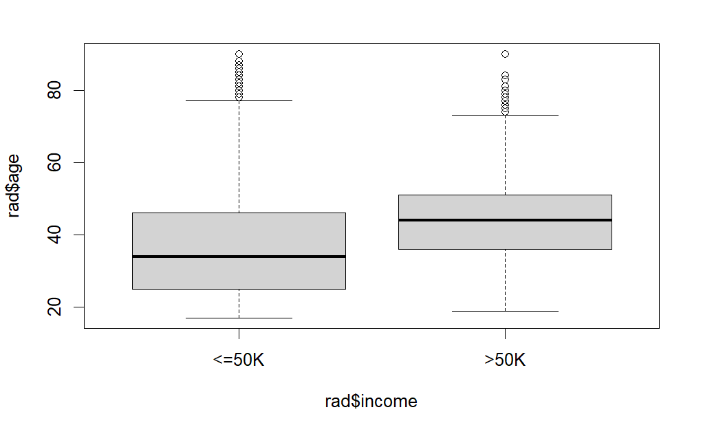

```r
library(gmodels)
#rad$income = as.factor(rad$income)
boxplot(rad$age~rad$income)
```

```r
CrossTable(rad$workclass, rad$income, chisq=TRUE)
```

```
   Cell Contents
|-------------------------|
|                       N |
| Chi-square contribution |
|           N / Row Total |
|           N / Col Total |
|         N / Table Total |
|-------------------------|


Total Observations in Table:  30725


                 | rad$income
   rad$workclass |     <=50K |      >50K | Row Total |
-----------------|-----------|-----------|-----------|
     Federal-gov |       589 |       371 |       960 |
                 |    24.159 |    72.871 |           |
                 |     0.614 |     0.386 |     0.031 |
                 |     0.026 |     0.048 |           |
                 |     0.019 |     0.012 |           |
-----------------|-----------|-----------|-----------|
       Local-gov |      1476 |       617 |      2093 |
                 |     5.848 |    17.640 |           |
                 |     0.705 |     0.295 |     0.068 |
                 |     0.064 |     0.081 |           |
                 |     0.048 |     0.020 |           |
-----------------|-----------|-----------|-----------|
    Never-worked |         7 |         0 |         7 |
                 |     0.578 |     1.743 |           |
                 |     1.000 |     0.000 |     0.000 |
                 |     0.000 |     0.000 |           |
                 |     0.000 |     0.000 |           |
-----------------|-----------|-----------|-----------|
         Private |     17733 |      4963 |     22696 |
                 |    27.763 |    83.744 |           |
                 |     0.781 |     0.219 |     0.739 |
                 |     0.768 |     0.649 |           |
                 |     0.577 |     0.162 |           |
-----------------|-----------|-----------|-----------|
```

[output cut: 20 more lines]

```
                 |     1.000 |     0.000 |     0.000 |
                 |     0.001 |     0.000 |           |
                 |     0.000 |     0.000 |           |
-----------------|-----------|-----------|-----------|
    Column Total |     23075 |      7650 |     30725 |
                 |     0.751 |     0.249 |           |
-----------------|-----------|-----------|-----------|


Statistics for All Table Factors


Pearson's Chi-squared test
------------------------------------------------------------
Chi^2 =  827.7184     d.f. =  7     p =  1.933848e-174
```

```r
t.test(rad$age~rad$income, alternative="two.sided")
```

```
    Welch Two Sample t-test

data:  rad$age by rad$income
t = -50.264, df = 17411, p-value < 2.2e-16
alternative hypothesis: true difference in means between group <=50K and group >50K is not equal to 0
95 percent confidence interval:
 -7.757250 -7.174955
sample estimates:
mean in group <=50K  mean in group >50K
           36.78374            44.24984
```

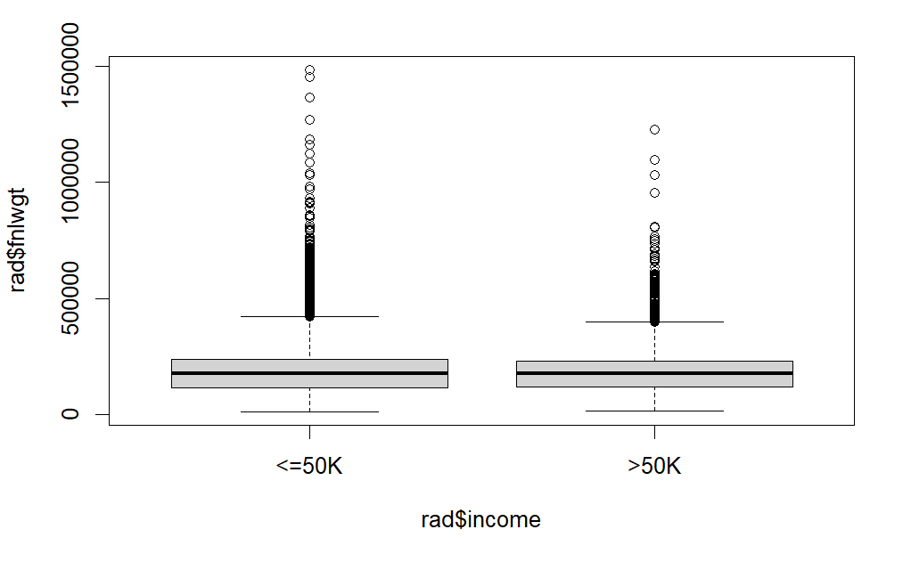

```r
boxplot(rad$fnlwgt~rad$income)
```

```r
CrossTable(rad$education, rad$income, chisq=TRUE)
```

```
   Cell Contents
|-------------------------|
|                       N |
| Chi-square contribution |
|           N / Row Total |
|           N / Col Total |
|         N / Table Total |
|-------------------------|


Total Observations in Table:  32561


              | rad$income
rad$education |     <=50K |      >50K | Row Total |
--------------|-----------|-----------|-----------|
         10th |       871 |        62 |       933 |
              |    37.360 |   117.784 |           |
              |     0.934 |     0.066 |     0.029 |
              |     0.035 |     0.008 |           |
              |     0.027 |     0.002 |           |
--------------|-----------|-----------|-----------|
         11th |      1115 |        60 |      1175 |
              |    55.723 |   175.674 |           |
              |     0.949 |     0.051 |     0.036 |
              |     0.045 |     0.008 |           |
              |     0.034 |     0.002 |           |
--------------|-----------|-----------|-----------|
         12th |       400 |        33 |       433 |
              |    15.452 |    48.715 |           |
              |     0.924 |     0.076 |     0.013 |
              |     0.016 |     0.004 |           |
              |     0.012 |     0.001 |           |
--------------|-----------|-----------|-----------|
      1st-4th |       162 |         6 |       168 |
              |     9.308 |    29.346 |           |
              |     0.964 |     0.036 |     0.005 |
              |     0.007 |     0.001 |           |
              |     0.005 |     0.000 |           |
--------------|-----------|-----------|-----------|
```

[output cut: 68 more lines]

```
              |     0.810 |     0.190 |     0.224 |
              |     0.239 |     0.177 |           |
              |     0.181 |     0.043 |           |
--------------|-----------|-----------|-----------|
 Column Total |     24720 |      7841 |     32561 |
              |     0.759 |     0.241 |           |
--------------|-----------|-----------|-----------|


Statistics for All Table Factors


Pearson's Chi-squared test
------------------------------------------------------------
Chi^2 =  4429.653     d.f. =  15     p =  0
```

```r
t.test(rad$fnlwgt~rad$income, alternative="two.sided")
```

```
    Welch Two Sample t-test

data:  rad$fnlwgt by rad$income
t = 1.7412, df = 13615, p-value = 0.08167
alternative hypothesis: true difference in means between group <=50K and group >50K is not equal to 0
95 percent confidence interval:
 -293.7029 4965.4332
sample estimates:
mean in group <=50K  mean in group >50K
           190340.9            188005.0
```

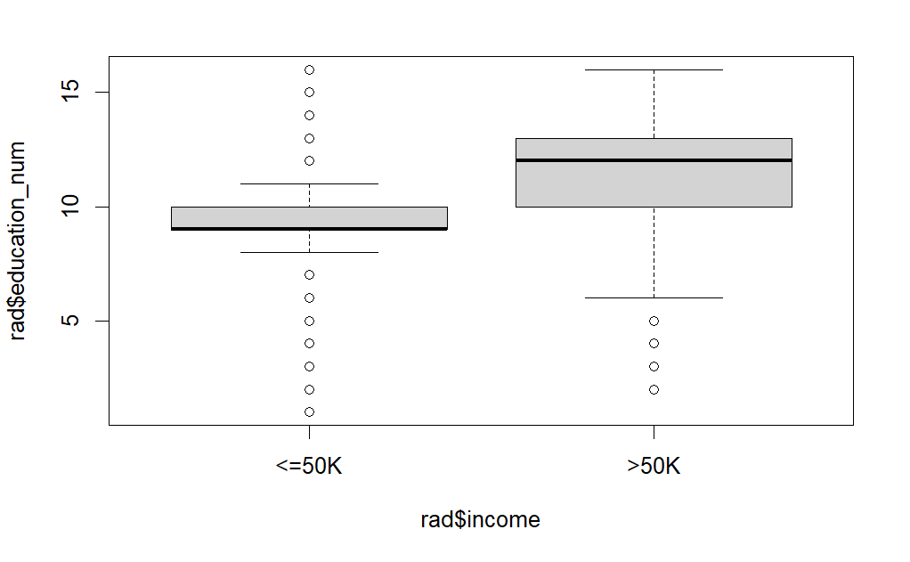

```r
boxplot(rad$education_num~rad$income)
```

```r
t.test(rad$education_num~rad$income, alternative="two.sided")
```

```
    Welch Two Sample t-test

data:  rad$education_num by rad$income
t = -64.896, df = 13421, p-value < 2.2e-16
alternative hypothesis: true difference in means between group <=50K and group >50K is not equal to 0
95 percent confidence interval:
 -2.077502 -1.955682
sample estimates:
mean in group <=50K  mean in group >50K
           9.595065           11.611657
```

```r
CrossTable(rad$marital_status, rad$income, chisq=TRUE)
```

```
   Cell Contents
|-------------------------|
|                       N |
| Chi-square contribution |
|           N / Row Total |
|           N / Col Total |
|         N / Table Total |
|-------------------------|


Total Observations in Table:  32561


                      | rad$income
   rad$marital_status |     <=50K |      >50K | Row Total |
----------------------|-----------|-----------|-----------|
             Divorced |      3980 |       463 |      4443 |
                      |   109.202 |   344.277 |           |
                      |     0.896 |     0.104 |     0.136 |
                      |     0.161 |     0.059 |           |
                      |     0.122 |     0.014 |           |
----------------------|-----------|-----------|-----------|
    Married-AF-spouse |        13 |        10 |        23 |
                      |     1.140 |     3.594 |           |
                      |     0.565 |     0.435 |     0.001 |
                      |     0.001 |     0.001 |           |
                      |     0.000 |     0.000 |           |
----------------------|-----------|-----------|-----------|
   Married-civ-spouse |      8284 |      6692 |     14976 |
                      |   837.419 |  2640.097 |           |
                      |     0.553 |     0.447 |     0.460 |
                      |     0.335 |     0.853 |           |
                      |     0.254 |     0.206 |           |
----------------------|-----------|-----------|-----------|
Married-spouse-absent |       384 |        34 |       418 |
                      |    14.002 |    44.143 |           |
                      |     0.919 |     0.081 |     0.013 |
                      |     0.016 |     0.004 |           |
                      |     0.012 |     0.001 |           |
----------------------|-----------|-----------|-----------|
```

[output cut: 14 more lines]

```
                      |     0.914 |     0.086 |     0.030 |
                      |     0.037 |     0.011 |           |
                      |     0.028 |     0.003 |           |
----------------------|-----------|-----------|-----------|
         Column Total |     24720 |      7841 |     32561 |
                      |     0.759 |     0.241 |           |
----------------------|-----------|-----------|-----------|


Statistics for All Table Factors


Pearson's Chi-squared test
------------------------------------------------------------
Chi^2 =  6517.742     d.f. =  6     p =  0
```

```r
CrossTable(rad$occupation, rad$income, chisq=TRUE)
```

```
   Cell Contents
|-------------------------|
|                       N |
| Chi-square contribution |
|           N / Row Total |
|           N / Col Total |
|         N / Table Total |
|-------------------------|


Total Observations in Table:  30718


                  | rad$income
   rad$occupation |     <=50K |      >50K | Row Total |
------------------|-----------|-----------|-----------|
     Adm-clerical |      3263 |       507 |      3770 |
                  |    65.882 |   198.662 |           |
                  |     0.866 |     0.134 |     0.123 |
                  |     0.141 |     0.066 |           |
                  |     0.106 |     0.017 |           |
------------------|-----------|-----------|-----------|
     Armed-Forces |         8 |         1 |         9 |
                  |     0.228 |     0.688 |           |
                  |     0.889 |     0.111 |     0.000 |
                  |     0.000 |     0.000 |           |
                  |     0.000 |     0.000 |           |
------------------|-----------|-----------|-----------|
     Craft-repair |      3170 |       929 |      4099 |
                  |     2.739 |     8.258 |           |
                  |     0.773 |     0.227 |     0.133 |
                  |     0.137 |     0.121 |           |
                  |     0.103 |     0.030 |           |
------------------|-----------|-----------|-----------|
  Exec-managerial |      2098 |      1968 |      4066 |
                  |   298.944 |   901.444 |           |
                  |     0.516 |     0.484 |     0.132 |
                  |     0.091 |     0.257 |           |
                  |     0.068 |     0.064 |           |
------------------|-----------|-----------|-----------|
```

[output cut: 56 more lines]

```
                  |     0.800 |     0.200 |     0.052 |
                  |     0.055 |     0.042 |           |
                  |     0.042 |     0.010 |           |
------------------|-----------|-----------|-----------|
     Column Total |     23068 |      7650 |     30718 |
                  |     0.751 |     0.249 |           |
------------------|-----------|-----------|-----------|


Statistics for All Table Factors


Pearson's Chi-squared test
------------------------------------------------------------
Chi^2 =  3744.899     d.f. =  13     p =  0
```

```r
CrossTable(rad$relationship, rad$income, chisq=TRUE)
```

```
   Cell Contents
|-------------------------|
|                       N |
| Chi-square contribution |
|           N / Row Total |
|           N / Col Total |
|         N / Table Total |
|-------------------------|


Total Observations in Table:  32561


                 | rad$income
rad$relationship |     <=50K |      >50K | Row Total |
-----------------|-----------|-----------|-----------|
         Husband |      7275 |      5918 |     13193 |
                 |   750.108 |  2364.834 |           |
                 |     0.551 |     0.449 |     0.405 |
                 |     0.294 |     0.755 |           |
                 |     0.223 |     0.182 |           |
-----------------|-----------|-----------|-----------|
   Not-in-family |      7449 |       856 |      8305 |
                 |   207.541 |   654.305 |           |
                 |     0.897 |     0.103 |     0.255 |
                 |     0.301 |     0.109 |           |
                 |     0.229 |     0.026 |           |
-----------------|-----------|-----------|-----------|
  Other-relative |       944 |        37 |       981 |
                 |    53.298 |   168.029 |           |
                 |     0.962 |     0.038 |     0.030 |
                 |     0.038 |     0.005 |           |
                 |     0.029 |     0.001 |           |
-----------------|-----------|-----------|-----------|
       Own-child |      5001 |        67 |      5068 |
                 |   345.772 |  1090.101 |           |
                 |     0.987 |     0.013 |     0.156 |
                 |     0.202 |     0.009 |           |
                 |     0.154 |     0.002 |           |
-----------------|-----------|-----------|-----------|
```

[output cut: 8 more lines]

```
                 |     0.525 |     0.475 |     0.048 |
                 |     0.033 |     0.095 |           |
                 |     0.025 |     0.023 |           |
-----------------|-----------|-----------|-----------|
    Column Total |     24720 |      7841 |     32561 |
                 |     0.759 |     0.241 |           |
-----------------|-----------|-----------|-----------|


Statistics for All Table Factors


Pearson's Chi-squared test
------------------------------------------------------------
Chi^2 =  6699.077     d.f. =  5     p =  0
```

```r
CrossTable(rad$race, rad$income, chisq=TRUE)
```

```
   Cell Contents
|-------------------------|
|                       N |
| Chi-square contribution |
|           N / Row Total |
|           N / Col Total |
|         N / Table Total |
|-------------------------|


Total Observations in Table:  32561


                   | rad$income
          rad$race |     <=50K |      >50K | Row Total |
-------------------|-----------|-----------|-----------|
Amer-Indian-Eskimo |       275 |        36 |       311 |
                   |     6.406 |    20.197 |           |
                   |     0.884 |     0.116 |     0.010 |
                   |     0.011 |     0.005 |           |
                   |     0.008 |     0.001 |           |
-------------------|-----------|-----------|-----------|
Asian-Pac-Islander |       763 |       276 |      1039 |
                   |     0.844 |     2.660 |           |
                   |     0.734 |     0.266 |     0.032 |
                   |     0.031 |     0.035 |           |
                   |     0.023 |     0.008 |           |
-------------------|-----------|-----------|-----------|
             Black |      2737 |       387 |      3124 |
                   |    56.262 |   177.373 |           |
                   |     0.876 |     0.124 |     0.096 |
                   |     0.111 |     0.049 |           |
                   |     0.084 |     0.012 |           |
-------------------|-----------|-----------|-----------|
             Other |       246 |        25 |       271 |
                   |     7.878 |    24.837 |           |
                   |     0.908 |     0.092 |     0.008 |
                   |     0.010 |     0.003 |           |
                   |     0.008 |     0.001 |           |
-------------------|-----------|-----------|-----------|
             White |     20699 |      7117 |     27816 |
                   |     8.299 |    26.165 |           |
                   |     0.744 |     0.256 |     0.854 |
                   |     0.837 |     0.908 |           |
                   |     0.636 |     0.219 |           |
-------------------|-----------|-----------|-----------|
      Column Total |     24720 |      7841 |     32561 |
                   |     0.759 |     0.241 |           |
-------------------|-----------|-----------|-----------|


Statistics for All Table Factors


Pearson's Chi-squared test
------------------------------------------------------------
Chi^2 =  330.9204     d.f. =  4     p =  2.305961e-70
```

```r
CrossTable(rad$sex, rad$income, chisq=TRUE)
```

```
   Cell Contents
|-------------------------|
|                       N |
| Chi-square contribution |
|           N / Row Total |
|           N / Col Total |
|         N / Table Total |
|-------------------------|


Total Observations in Table:  32561


             | rad$income
     rad$sex |     <=50K |      >50K | Row Total |
-------------|-----------|-----------|-----------|
      Female |      9592 |      1179 |     10771 |
             |   244.770 |   771.677 |           |
             |     0.891 |     0.109 |     0.331 |
             |     0.388 |     0.150 |           |
             |     0.295 |     0.036 |           |
-------------|-----------|-----------|-----------|
        Male |     15128 |      6662 |     21790 |
             |   120.992 |   381.447 |           |
             |     0.694 |     0.306 |     0.669 |
             |     0.612 |     0.850 |           |
             |     0.465 |     0.205 |           |
-------------|-----------|-----------|-----------|
Column Total |     24720 |      7841 |     32561 |
             |     0.759 |     0.241 |           |
-------------|-----------|-----------|-----------|


Statistics for All Table Factors


Pearson's Chi-squared test
------------------------------------------------------------
Chi^2 =  1518.887     d.f. =  1     p =  0

Pearson's Chi-squared test with Yates' continuity correction
------------------------------------------------------------
Chi^2 =  1517.813     d.f. =  1     p =  0
```

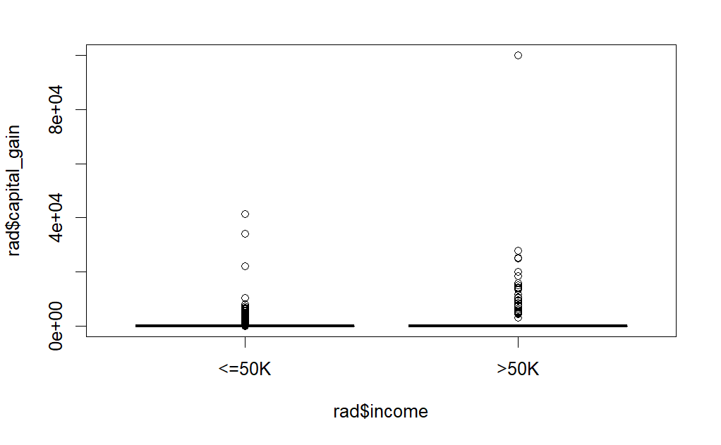

```r
boxplot(rad$capital_gain~rad$income)
```

```r
t.test(rad$capital_gain~rad$income, alternative="two.sided")
```

```
    Welch Two Sample t-test

data:  rad$capital_gain by rad$income
t = -23.427, df = 7861.7, p-value < 2.2e-16
alternative hypothesis: true difference in means between group <=50K and group >50K is not equal to 0
95 percent confidence interval:
 -4180.166 -3534.614
sample estimates:
mean in group <=50K  mean in group >50K
           148.7525           4006.1425
```

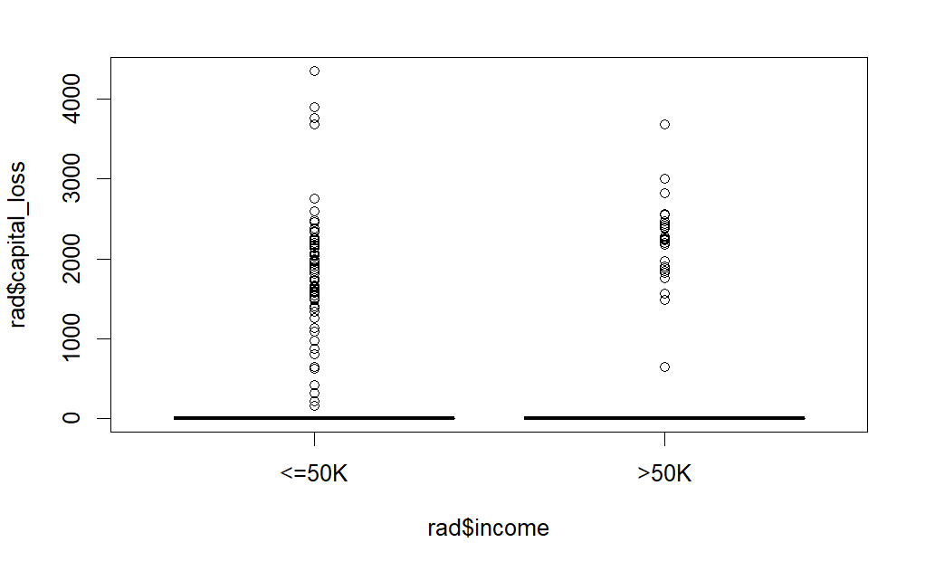

```r
boxplot(rad$capital_loss~rad$income)
```

```r
t.test(rad$capital_loss~rad$income, alternative="two.sided")
```

```
    Welch Two Sample t-test

data:  rad$capital_loss by rad$income
t = -20.238, df = 9231.1, p-value < 2.2e-16
alternative hypothesis: true difference in means between group <=50K and group >50K is not equal to 0
95 percent confidence interval:
 -155.5985 -128.1187
sample estimates:
mean in group <=50K  mean in group >50K
           53.14292           195.00153
```

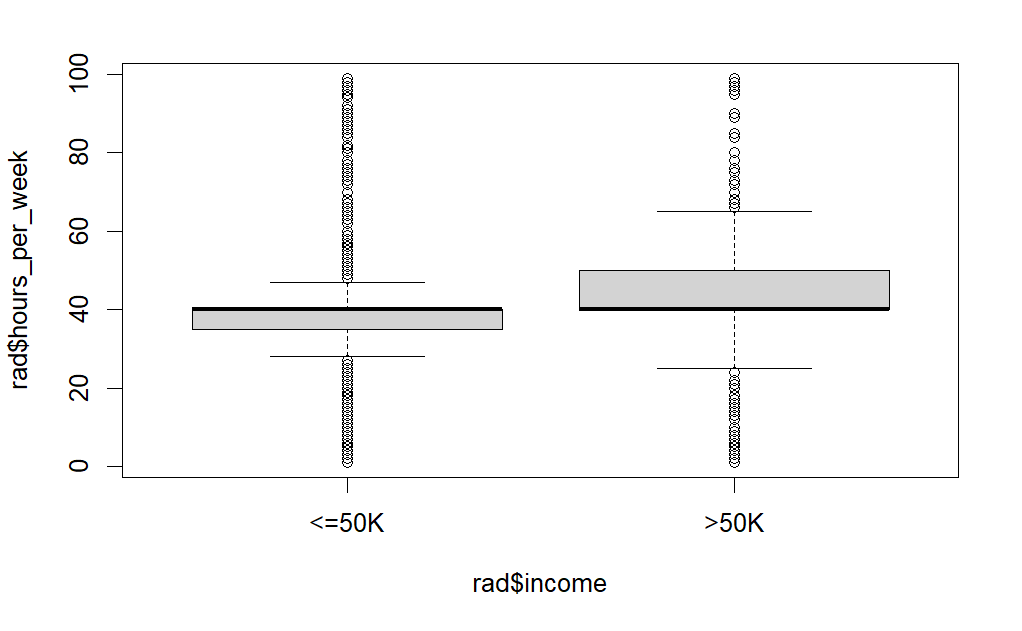

```r
boxplot(rad$hours_per_week~rad$income)
```

```r
t.test(rad$hours_per_week~rad$income, alternative="two.sided")
```

```
    Welch Two Sample t-test

data:  rad$hours_per_week by rad$income
t = -45.123, df = 14570, p-value < 2.2e-16
alternative hypothesis: true difference in means between group <=50K and group >50K is not equal to 0
95 percent confidence interval:
 -6.920943 -6.344690
sample estimates:
mean in group <=50K  mean in group >50K
           38.84021            45.47303
```

```r
CrossTable(rad$native_country, rad$income, chisq=TRUE)
```

```
   Cell Contents
|-------------------------|
|                       N |
| Chi-square contribution |
|           N / Row Total |
|           N / Col Total |
|         N / Table Total |
|-------------------------|


Total Observations in Table:  31978


                           | rad$income
        rad$native_country |     <=50K |      >50K | Row Total |
---------------------------|-----------|-----------|-----------|
                  Cambodia |        12 |         7 |        19 |
                           |     0.409 |     1.289 |           |
                           |     0.632 |     0.368 |     0.001 |
                           |     0.000 |     0.001 |           |
                           |     0.000 |     0.000 |           |
---------------------------|-----------|-----------|-----------|
                    Canada |        82 |        39 |       121 |
                           |     1.063 |     3.355 |           |
                           |     0.678 |     0.322 |     0.004 |
                           |     0.003 |     0.005 |           |
                           |     0.003 |     0.001 |           |
---------------------------|-----------|-----------|-----------|
                     China |        55 |        20 |        75 |
                           |     0.067 |     0.211 |           |
                           |     0.733 |     0.267 |     0.002 |
                           |     0.002 |     0.003 |           |
                           |     0.002 |     0.001 |           |
---------------------------|-----------|-----------|-----------|
                  Columbia |        57 |         2 |        59 |
                           |     3.321 |    10.479 |           |
                           |     0.966 |     0.034 |     0.002 |
                           |     0.002 |     0.000 |           |
                           |     0.002 |     0.000 |           |
---------------------------|-----------|-----------|-----------|
```

[output cut: 218 more lines]

```
                           |     0.625 |     0.375 |     0.001 |
                           |     0.000 |     0.001 |           |
                           |     0.000 |     0.000 |           |
---------------------------|-----------|-----------|-----------|
              Column Total |     24283 |      7695 |     31978 |
                           |     0.759 |     0.241 |           |
---------------------------|-----------|-----------|-----------|


Statistics for All Table Factors


Pearson's Chi-squared test
------------------------------------------------------------
Chi^2 =  317.0877     d.f. =  40     p =  8.280446e-45
```

ans: associated - workclass, education, occupation, hours_per_week

5. Change all the “?” characters in the dataframe to NA

```r
replace(rad, "?", NA)
```

| age | workclass | fnlwgt | education | education_num | marital_status | occupation | relationship | race | sex | capital_gain | capital_loss | hours_per_week | native_country | income | ? |
| --- | --- | --- | --- | --- | --- | --- | --- | --- | --- | --- | --- | --- | --- | --- | --- |
| 39 | State-gov | 77516 | Bachelors | 13 | Never-married | Adm-clerical | Not-in-family | White | Male | 2174 | 0 | 40 | United-States | <=50K | NA |
| 50 | Self-emp-not-inc | 83311 | Bachelors | 13 | Married-civ-spouse | Exec-managerial | Husband | White | Male | 0 | 0 | 13 | United-States | <=50K | NA |
| 38 | Private | 215646 | HS-grad | 9 | Divorced | Handlers-cleaners | Not-in-family | White | Male | 0 | 0 | 40 | United-States | <=50K | NA |
| 53 | Private | 234721 | 11th | 7 | Married-civ-spouse | Handlers-cleaners | Husband | Black | Male | 0 | 0 | 40 | United-States | <=50K | NA |
| 28 | Private | 338409 | Bachelors | 13 | Married-civ-spouse | Prof-specialty | Wife | Black | Female | 0 | 0 | 40 | Cuba | <=50K | NA |
| 37 | Private | 284582 | Masters | 14 | Married-civ-spouse | Exec-managerial | Wife | White | Female | 0 | 0 | 40 | United-States | <=50K | NA |
| 49 | Private | 160187 | 9th | 5 | Married-spouse-absent | Other-service | Not-in-family | Black | Female | 0 | 0 | 16 | Jamaica | <=50K | NA |
| 52 | Self-emp-not-inc | 209642 | HS-grad | 9 | Married-civ-spouse | Exec-managerial | Husband | White | Male | 0 | 0 | 45 | United-States | >50K | NA |
| 31 | Private | 45781 | Masters | 14 | Never-married | Prof-specialty | Not-in-family | White | Female | 14084 | 0 | 50 | United-States | >50K | NA |
| 42 | Private | 159449 | Bachelors | 13 | Married-civ-spouse | Exec-managerial | Husband | White | Male | 5178 | 0 | 40 | United-States | >50K | NA |

[output cut: 990 more lines]

6)Which columns have missing values?

```r
colSums(is.na(rad))
```

```
           age      workclass         fnlwgt      education  education_num
             0           1836              0              0              0
marital_status     occupation   relationship           race            sex
             0           1843              0              0              0
  capital_gain   capital_loss hours_per_week native_country         income
             0              0              0            583              0
```

7)data imputation

```r
replaceNA= function(x){
  if(is.integer(x))
    x[is.na(x)]= mean(x, na.rm = TRUE)
  else{
    t1 = table(x)
    mode = names(which(t1==max(t1)))
    x[is.na(x)]= mode

  }
  return(x)
}
rad_as=sapply(rad, replaceNA)
rad_as
```

```
         age  workclass          fnlwgt    education      education_num
    [1,] "39" "State-gov"        "77516"   "Bachelors"    "13"
    [2,] "50" "Self-emp-not-inc" "83311"   "Bachelors"    "13"
    [3,] "38" "Private"          "215646"  "HS-grad"      "9"
    [4,] "53" "Private"          "234721"  "11th"         "7"
    [5,] "28" "Private"          "338409"  "Bachelors"    "13"
    [6,] "37" "Private"          "284582"  "Masters"      "14"
    [7,] "49" "Private"          "160187"  "9th"          "5"
    [8,] "52" "Self-emp-not-inc" "209642"  "HS-grad"      "9"
    [9,] "31" "Private"          "45781"   "Masters"      "14"
   [10,] "42" "Private"          "159449"  "Bachelors"    "13"
   [11,] "37" "Private"          "280464"  "Some-college" "10"
   [12,] "30" "State-gov"        "141297"  "Bachelors"    "13"
   [13,] "23" "Private"          "122272"  "Bachelors"    "13"
   [14,] "32" "Private"          "205019"  "Assoc-acdm"   "12"
```

[output cut: 254 more lines]

```r
rad_as=as.data.frame(rad_as)
str(rad_as)
```

```
'data.frame':   32561 obs. of  15 variables:
 $ age           : chr  "39" "50" "38" "53" ...
 $ workclass     : chr  "State-gov" "Self-emp-not-inc" "Private" "Private" ...
 $ fnlwgt        : chr  "77516" "83311" "215646" "234721" ...
 $ education     : chr  "Bachelors" "Bachelors" "HS-grad" "11th" ...
 $ education_num : chr  "13" "13" "9" "7" ...
 $ marital_status: chr  "Never-married" "Married-civ-spouse" "Divorced" "Married-civ-spouse" ...
 $ occupation    : chr  "Adm-clerical" "Exec-managerial" "Handlers-cleaners" "Handlers-cleaners" ...
 $ relationship  : chr  "Not-in-family" "Husband" "Not-in-family" "Husband" ...
 $ race          : chr  "White" "White" "White" "Black" ...
 $ sex           : chr  "Male" "Male" "Male" "Male" ...
 $ capital_gain  : chr  "2174" "0" "0" "0" ...
 $ capital_loss  : chr  "0" "0" "0" "0" ...
 $ hours_per_week: chr  "40" "13" "40" "40" ...
 $ native_country: chr  "United-States" "United-States" "United-States" "United-States" ...
 $ income        : chr  "<=50K" "<=50K" "<=50K" "<=50K" ...
```

```r
colSums(is.na(rad_as))
```

```
           age      workclass         fnlwgt      education  education_num
             0              0              0              0              0
marital_status     occupation   relationship           race            sex
             0              0              0              0              0
  capital_gain   capital_loss hours_per_week native_country         income
             0              0              0              0              0
```

8)Set the seed of the random number generator to a fixed integer, say 1

```r
set.seed(1)
```

9)Randomize the order of the rows in the dataset

```r
set.seed(1)
rad = rad[sample(nrow(rad_as), replace=FALSE), ]
#rad
```

10)setting variables back to the integer

```r
#install.packages("mltools")
library(mltools)
library(data.table)
rad_as$age=as.integer(rad_as$age)
rad_as$fnlwgt=as.integer(rad_as$fnlwgt)
rad_as$education_num=as.integer(rad_as$education_num)
rad_as$capital_gain=as.integer(rad_as$capital_gain)
rad_as$capital_loss=as.integer(rad_as$capital_loss)
rad_as$hours_per_week=as.integer(rad_as$hours_per_week)
str(rad_as)
```

```
'data.frame':   32561 obs. of  15 variables:
 $ age           : int  39 50 38 53 28 37 49 52 31 42 ...
 $ workclass     : chr  "State-gov" "Self-emp-not-inc" "Private" "Private" ...
 $ fnlwgt        : int  77516 83311 215646 234721 338409 284582 160187 209642 45781 159449 ...
 $ education     : chr  "Bachelors" "Bachelors" "HS-grad" "11th" ...
 $ education_num : int  13 13 9 7 13 14 5 9 14 13 ...
 $ marital_status: chr  "Never-married" "Married-civ-spouse" "Divorced" "Married-civ-spouse" ...
 $ occupation    : chr  "Adm-clerical" "Exec-managerial" "Handlers-cleaners" "Handlers-cleaners" ...
 $ relationship  : chr  "Not-in-family" "Husband" "Not-in-family" "Husband" ...
 $ race          : chr  "White" "White" "White" "Black" ...
 $ sex           : chr  "Male" "Male" "Male" "Male" ...
 $ capital_gain  : int  2174 0 0 0 0 0 0 0 14084 5178 ...
 $ capital_loss  : int  0 0 0 0 0 0 0 0 0 0 ...
 $ hours_per_week: int  40 13 40 40 40 40 16 45 50 40 ...
 $ native_country: chr  "United-States" "United-States" "United-States" "United-States" ...
 $ income        : chr  "<=50K" "<=50K" "<=50K" "<=50K" ...
```

```r
as.data.table(rad_as)
```

| age | workclass | fnlwgt | education | education_num | marital_status | occupation | relationship | race | sex | capital_gain | capital_loss | hours_per_week | native_country | income |
| --- | --- | --- | --- | --- | --- | --- | --- | --- | --- | --- | --- | --- | --- | --- |
| 39 | State-gov | 77516 | Bachelors | 13 | Never-married | Adm-clerical | Not-in-family | White | Male | 2174 | 0 | 40 | United-States | <=50K |
| 50 | Self-emp-not-inc | 83311 | Bachelors | 13 | Married-civ-spouse | Exec-managerial | Husband | White | Male | 0 | 0 | 13 | United-States | <=50K |
| 38 | Private | 215646 | HS-grad | 9 | Divorced | Handlers-cleaners | Not-in-family | White | Male | 0 | 0 | 40 | United-States | <=50K |
| 53 | Private | 234721 | 11th | 7 | Married-civ-spouse | Handlers-cleaners | Husband | Black | Male | 0 | 0 | 40 | United-States | <=50K |
| 28 | Private | 338409 | Bachelors | 13 | Married-civ-spouse | Prof-specialty | Wife | Black | Female | 0 | 0 | 40 | Cuba | <=50K |
| 37 | Private | 284582 | Masters | 14 | Married-civ-spouse | Exec-managerial | Wife | White | Female | 0 | 0 | 40 | United-States | <=50K |
| 49 | Private | 160187 | 9th | 5 | Married-spouse-absent | Other-service | Not-in-family | Black | Female | 0 | 0 | 16 | Jamaica | <=50K |
| 52 | Self-emp-not-inc | 209642 | HS-grad | 9 | Married-civ-spouse | Exec-managerial | Husband | White | Male | 0 | 0 | 45 | United-States | >50K |
| 31 | Private | 45781 | Masters | 14 | Never-married | Prof-specialty | Not-in-family | White | Female | 14084 | 0 | 50 | United-States | >50K |
| 42 | Private | 159449 | Bachelors | 13 | Married-civ-spouse | Exec-managerial | Husband | White | Male | 5178 | 0 | 40 | United-States | >50K |

[output cut: 990 more lines]

```r
#rad_as=as.data.frame(rad_as)
```

one-hot-encoding of all unordered categorical variables

```r
library(caret)

#rad_d1 = select(rad,workclass,education,marital_status,occupation,relationship,race,sex,native_country)
#class(rad_d1)


rad_as$workclass= as.factor(rad_as$workclass)
rad_as$education= as.factor(rad_as$education)
rad_as$marital_status= as.factor(rad_as$marital_status)
rad_as$occupation= as.factor(rad_as$occupation)
rad_as$relationship= as.factor(rad_as$relationship)
rad_as$race= as.factor(rad_as$race)
rad_as$sex= as.factor(rad_as$sex)
rad_as$native_country= as.factor(rad_as$native_country)

rad_d1 = as.data.frame(rad_as[,c("workclass","education","marital_status","occupation","relationship","race","sex","native_country")])


rad_d1 =as.data.table(rad_d1)
rad_d1
```

| workclass | education | marital_status | occupation | relationship | race | sex | native_country |
| --- | --- | --- | --- | --- | --- | --- | --- |
| State-gov | Bachelors | Never-married | Adm-clerical | Not-in-family | White | Male | United-States |
| Self-emp-not-inc | Bachelors | Married-civ-spouse | Exec-managerial | Husband | White | Male | United-States |
| Private | HS-grad | Divorced | Handlers-cleaners | Not-in-family | White | Male | United-States |
| Private | 11th | Married-civ-spouse | Handlers-cleaners | Husband | Black | Male | United-States |
| Private | Bachelors | Married-civ-spouse | Prof-specialty | Wife | Black | Female | Cuba |
| Private | Masters | Married-civ-spouse | Exec-managerial | Wife | White | Female | United-States |
| Private | 9th | Married-spouse-absent | Other-service | Not-in-family | Black | Female | Jamaica |
| Self-emp-not-inc | HS-grad | Married-civ-spouse | Exec-managerial | Husband | White | Male | United-States |
| Private | Masters | Never-married | Prof-specialty | Not-in-family | White | Female | United-States |
| Private | Bachelors | Married-civ-spouse | Exec-managerial | Husband | White | Male | United-States |

[output cut: 990 more lines]

```r
str(rad_d1)
```

```
Classes ‘data.table’ and 'data.frame':  32561 obs. of  8 variables:
 $ workclass     : Factor w/ 8 levels "Federal-gov",..: 7 6 4 4 4 4 4 6 4 4 ...
 $ education     : Factor w/ 16 levels "10th","11th",..: 10 10 12 2 10 13 7 12 13 10 ...
 $ marital_status: Factor w/ 7 levels "Divorced","Married-AF-spouse",..: 5 3 1 3 3 3 4 3 5 3 ...
 $ occupation    : Factor w/ 14 levels "Adm-clerical",..: 1 4 6 6 10 4 8 4 10 4 ...
 $ relationship  : Factor w/ 6 levels "Husband","Not-in-family",..: 2 1 2 1 6 6 2 1 2 1 ...
 $ race          : Factor w/ 5 levels "Amer-Indian-Eskimo",..: 5 5 5 3 3 5 3 5 5 5 ...
 $ sex           : Factor w/ 2 levels "Female","Male": 2 2 2 2 1 1 1 2 1 2 ...
 $ native_country: Factor w/ 41 levels "Cambodia","Canada",..: 39 39 39 39 5 39 23 39 39 39 ...
 - attr(*, ".internal.selfref")=<externalptr>
```

```r
rad_d1OneHotEncoded=one_hot(rad_d1, sparsifyNAs= TRUE, naCols= TRUE, dropCols= TRUE, dropUnusedLevels=TRUE)
rad_d1OneHotEncoded=as.data.frame(rad_d1OneHotEncoded)
```

```r
rad$income = as.factor(rad$income)
```

11)Scaling all numeric features using Min-Max scaling

```r
str(rad$income)
```

```
 Factor w/ 2 levels "<=50K",">50K": 1 1 1 2 1 1 1 1 1 1 ...
```

```r
rad_n112 = as.data.frame(rad[c("age","fnlwgt","education_num","capital_gain","capital_loss","hours_per_week")])
str(rad_n112)
```

```
'data.frame':   32561 obs. of  6 variables:
 $ age           : int  51 38 30 38 21 34 33 66 38 28 ...
 $ fnlwgt        : int  441637 115289 53158 172538 200973 80058 90668 185336 108140 25955 ...
 $ education_num : int  9 9 12 13 10 15 9 9 13 11 ...
 $ capital_gain  : int  0 0 0 0 0 0 0 0 0 0 ...
 $ capital_loss  : int  0 0 0 1977 0 0 0 0 0 0 ...
 $ hours_per_week: int  40 40 40 40 20 50 40 35 20 40 ...
```

```r
normalize <- function(x) {
 return ((x - min(x)) / (max(x) - min(x)))
}

rad_n112 = as.data.frame(lapply(rad_n112, normalize))
rad_n112
```

| age | fnlwgt | education_num | capital_gain | capital_loss | hours_per_week |
| --- | --- | --- | --- | --- | --- |
| 0.46575342 | 0.291596148 | 0.53333333 | 0.000000000 | 0.0000000 | 0.39795918 |
| 0.28767123 | 0.069955583 | 0.53333333 | 0.000000000 | 0.0000000 | 0.39795918 |
| 0.17808219 | 0.027759063 | 0.73333333 | 0.000000000 | 0.0000000 | 0.39795918 |
| 0.28767123 | 0.108836473 | 0.80000000 | 0.000000000 | 0.4538567 | 0.39795918 |
| 0.05479452 | 0.128148219 | 0.60000000 | 0.000000000 | 0.0000000 | 0.19387755 |
| 0.23287671 | 0.046028307 | 0.93333333 | 0.000000000 | 0.0000000 | 0.50000000 |
| 0.21917808 | 0.053234132 | 0.53333333 | 0.000000000 | 0.0000000 | 0.39795918 |
| 0.67123288 | 0.117528287 | 0.53333333 | 0.000000000 | 0.0000000 | 0.34693878 |
| 0.28767123 | 0.065100311 | 0.80000000 | 0.000000000 | 0.0000000 | 0.19387755 |
| 0.15068493 | 0.009284036 | 0.66666667 | 0.000000000 | 0.0000000 | 0.39795918 |

[output cut: 990 more lines]

```r
rad_new1= cbind(rad_d1OneHotEncoded, rad_n112)
rad_new1
```

| workclass_Federal-gov | workclass_Local-gov | workclass_Never-worked | workclass_Private | workclass_Self-emp-inc | workclass_Self-emp-not-inc | workclass_State-gov | workclass_Without-pay | education_10th | education_11th | education_12th | education_1st-4th | education_5th-6th | education_7th-8th | education_9th | education_Assoc-acdm | education_Assoc-voc | education_Bachelors | education_Doctorate | education_HS-grad | education_Masters | education_Preschool | education_Prof-school | education_Some-college | marital_status_Divorced | marital_status_Married-AF-spouse | marital_status_Married-civ-spouse | marital_status_Married-spouse-absent | marital_status_Never-married | marital_status_Separated | … |
| --- | --- | --- | --- | --- | --- | --- | --- | --- | --- | --- | --- | --- | --- | --- | --- | --- | --- | --- | --- | --- | --- | --- | --- | --- | --- | --- | --- | --- | --- | --- |
| 0 | 0 | 0 | 0 | 0 | 0 | 1 | 0 | 0 | 0 | 0 | 0 | 0 | 0 | 0 | 0 | 0 | 1 | 0 | 0 | 0 | 0 | 0 | 0 | 0 | 0 | 0 | 0 | 1 | 0 | … |
| 0 | 0 | 0 | 0 | 0 | 1 | 0 | 0 | 0 | 0 | 0 | 0 | 0 | 0 | 0 | 0 | 0 | 1 | 0 | 0 | 0 | 0 | 0 | 0 | 0 | 0 | 1 | 0 | 0 | 0 | … |
| 0 | 0 | 0 | 1 | 0 | 0 | 0 | 0 | 0 | 0 | 0 | 0 | 0 | 0 | 0 | 0 | 0 | 0 | 0 | 1 | 0 | 0 | 0 | 0 | 1 | 0 | 0 | 0 | 0 | 0 | … |
| 0 | 0 | 0 | 1 | 0 | 0 | 0 | 0 | 0 | 1 | 0 | 0 | 0 | 0 | 0 | 0 | 0 | 0 | 0 | 0 | 0 | 0 | 0 | 0 | 0 | 0 | 1 | 0 | 0 | 0 | … |
| 0 | 0 | 0 | 1 | 0 | 0 | 0 | 0 | 0 | 0 | 0 | 0 | 0 | 0 | 0 | 0 | 0 | 1 | 0 | 0 | 0 | 0 | 0 | 0 | 0 | 0 | 1 | 0 | 0 | 0 | … |
| 0 | 0 | 0 | 1 | 0 | 0 | 0 | 0 | 0 | 0 | 0 | 0 | 0 | 0 | 0 | 0 | 0 | 0 | 0 | 0 | 1 | 0 | 0 | 0 | 0 | 0 | 1 | 0 | 0 | 0 | … |
| 0 | 0 | 0 | 1 | 0 | 0 | 0 | 0 | 0 | 0 | 0 | 0 | 0 | 0 | 1 | 0 | 0 | 0 | 0 | 0 | 0 | 0 | 0 | 0 | 0 | 0 | 0 | 1 | 0 | 0 | … |
| 0 | 0 | 0 | 0 | 0 | 1 | 0 | 0 | 0 | 0 | 0 | 0 | 0 | 0 | 0 | 0 | 0 | 0 | 0 | 1 | 0 | 0 | 0 | 0 | 0 | 0 | 1 | 0 | 0 | 0 | … |
| 0 | 0 | 0 | 1 | 0 | 0 | 0 | 0 | 0 | 0 | 0 | 0 | 0 | 0 | 0 | 0 | 0 | 0 | 0 | 0 | 1 | 0 | 0 | 0 | 0 | 0 | 0 | 0 | 1 | 0 | … |
| 0 | 0 | 0 | 1 | 0 | 0 | 0 | 0 | 0 | 0 | 0 | 0 | 0 | 0 | 0 | 0 | 0 | 1 | 0 | 0 | 0 | 0 | 0 | 0 | 0 | 0 | 1 | 0 | 0 | 0 | … |

[output cut: 990 more lines]

splitting datasets into train and test

```r
rad_train<-rad_new1[1:25000, ]
rad_test<-rad_new1[25001:32561, ]

rad_train_labels<-rad[1:25000, 15]
rad_test_labels<-rad[25001:32561, 15]
```

```r
library(caret)
rad_test_pred<-knn(train = rad_train, test = rad_test,cl=rad_train_labels ,k = 21)
```

```r
#rad_test_pred
```

```r
library(class)
folds1=createFolds(rad$income,k=5)
str(folds1)
```

```
List of 5
 $ Fold1: int [1:6512] 3 5 9 10 18 21 25 26 31 34 ...
 $ Fold2: int [1:6513] 2 13 16 17 19 20 23 24 28 32 ...
 $ Fold3: int [1:6512] 1 4 7 11 14 29 36 37 55 59 ...
 $ Fold4: int [1:6512] 6 22 27 30 38 39 40 47 52 60 ...
 $ Fold5: int [1:6512] 8 12 15 43 45 46 48 50 54 56 ...
```

```r
knn_fold=function(features,target,fold,k){
train=features[fold,]
validation=features[fold,]
train_labels=target[fold]
validation_labels=target[fold]
validation_preds=knn(train,validation,train_labels,k=k)
t= table(validation_labels,validation_preds)
#FPR=t[1,2]/(t[1,2]+t[1,1])
#FNR=t[2,1]/(t[2,1]+t[2,2])
#return (c("FPR"=FPR,"FNR"=FNR))
error=(t[1,2]+t[2,1])/(t[1,1]+t[1,2]+t[2,1]+t[2,2])
return(error)
}
```